# 3. Identifying DEGs comparing MUT vs WT cells of the same clonotype (21LT2)

Friederike Dündar

April 6; updated 2020-06-23

```r
library(data.table)
library(magrittr)
library(SingleCellExperiment)
library(ggplot2); theme_set(theme_bw(base_size = 16) )
library(ggrepel)
library(patchwork)
library(Klebanoff21LT2)
```

```r
## based on what we saw in `IdentifyingReactiveClonotype.Rmd`
winner <- "TRA:CAGNTGTASKLTF;TRB:CASSGLAGGPVSGANVLTF"
winner_TRB <- "TRB:CASSGLAGGPVSGANVLTF"
non_winner <- "TRA:CAGINAGGTSYGKLTF;TRB:CASSLVPGDAYEQYF" # clonotype with negative delta IFNg
```

```r
cdrs21LT2 <- list(winner, winner_TRB, non_winner)
usethis::use_data(cdrs21LT2)
```

# Identifying genes that are DE in MUT vs. WT cells of the same clonotype

The main goal of the bioinformatic analyses is to identify TCR clonotypes that show a selective response against the antigen presented by the APCs. These should include T cells that show high values for acute T cell activation, but the same clonotypes should *not* show significant activation when exposed to the irrelevant antigen. This is how we determined the “winning” clonotype: by simply assessing the difference of IFNG levels.

In principle, we’re expecting three groups of T cells:

- **specific responders**: higher activation in the presence of the tumor compared to the irrelevant antigen
- **unspecific responders**: similarly high activation markers in both antigen conditions;
- **non-responders**: no expression of activation markers.

Can we see those three groups using IFNG?

```r
## Load the SCE with the shared clonotypes
#sce.shared <- readRDS(file = "~/Documents/Projects/2018-10_Smita/data/sce_sharedClonotypes_Mar2020.RDS")
sce.shared <- load_21LT2shared()
```

```
#> Cached data here: /Users/frd2007/Library/Caches/BiocFileCache/2a2f2eabaf83_zu2gcbqpwekcl1ye1lo4qxlsudzoflxq.rds
#> Cached data here: /Users/frd2007/Library/Caches/BiocFileCache/2a2f98fd965_atvnpzltr0x2vh67pylc4i0t3ld6slc5.rds
#> Cached data here: /Users/frd2007/Library/Caches/BiocFileCache/2a2f43097aca_z3k2l6cv2ob7omghrf3e8ld1ok39r761.rds
#> Cached data here: /Users/frd2007/Library/Caches/BiocFileCache/2a2f235c8628_0pazpwx88lor2r20x3d6daut0vfxy1vb.rds
#> Cached data here: /Users/frd2007/Library/Caches/BiocFileCache/2a2ff6bbe3b_kgxx3t9n56gn4fip2t7wdih1cz2h2ddt.rds
```

```r
ifng.dt <- scABC2::make_long_dt(sce.shared,
  exprs_values = "logcounts", genes = "IFNG",
  include_metaData=c("Sample", "id"))
```

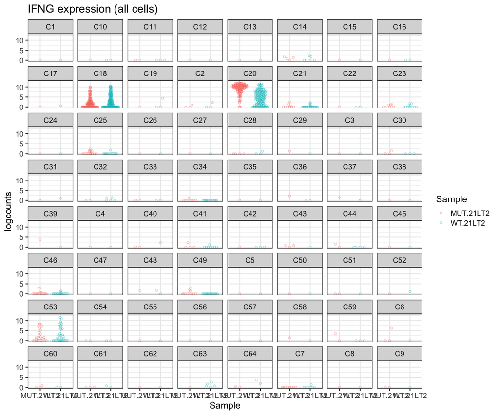

```r
ggplot(ifng.dt, aes(x = Sample, y = logcounts, color = Sample)) +
  ggbeeswarm::geom_quasirandom(alpha = .5, shape = 1, groupOnX = TRUE) +
  facet_wrap(~id) +
  guides(colir = FALSE) +
  ggtitle("IFNG expression (all cells)")
```

We can learn a couple of things from this plot:

1. Very few clonotypes are as abundantly present as C18, C20 and C53.

```r
data("clonotype_ids", package = "Klebanoff21LT2")
clonotype_ids[id %in% c("C18","C20","C53")] %>% .[, -"cdr3s_aa", with=FALSE] %>%
  unique %>% as.data.frame %>% knitr::kable(.)
```

| MUT.21LT2 | WT.21LT2 | TRA | TRB | id | cdr3s_consolidated | Patient |
| --- | --- | --- | --- | --- | --- | --- |
| 93 | 106 | TRA:CAGINAGGTSYGKLTF | TRB:CASSLVPGDAYEQYF | C18 | TRA:CAGINAGGTSYGKLTF;TRB:CASSLVPGDAYEQYF | 21LT2 |
| 124 | 148 | TRA:CAGNTGTASKLTF | TRB:CASSGLAGGPVSGANVLTF | C20 | TRA:CAGNTGTASKLTF;TRB:CASSGLAGGPVSGANVLTF | 21LT2 |
| 24 | 35 | TRA:CIVRGGKLIF | TRB:CASSLALGYLNTEAFF | C53 | TRA:CIVRGGKLIF;TRB:CASSLALGYLNTEAFF | 21LT2 |
| 11 | 8 | NA | TRB:CASSGLAGGPVSGANVLTF | C20 | TRA:CAGNTGTASKLTF;TRB:CASSGLAGGPVSGANVLTF | 21LT2 |
| 2 | 5 | NA | TRB:CASSLALGYLNTEAFF | C53 | TRA:CIVRGGKLIF;TRB:CASSLALGYLNTEAFF | 21LT2 |
| 58 | 91 | NA | TRB:CASSLVPGDAYEQYF | C18 | TRA:CAGINAGGTSYGKLTF;TRB:CASSLVPGDAYEQYF | 21LT2 |

2. C20 seems to be the one with the greatest difference in activation based on IFNG ($\Rightarrow$ corresponds to our winner TRB, too!)
3. C18 and C53 are examples of **unspecific responders** because the IFNG levels are more or less similar in both conditions.

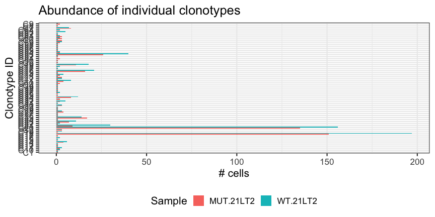

```r
ifng.dt[, .N, c("Sample","id")] %>%
 ggplot(., aes(x = id, y = N, fill = Sample)) +
  geom_bar(stat = "identity",
      position = position_dodge()) +
  coord_flip() +
  ggtitle("Abundance of individual clonotypes") +
  ylab("# cells") + xlab("Clonotype ID") +
  theme(legend.position = "bottom")
```

## Differentially expressed genes: MUT vs. WT

```r
#data("shared_clonotype_ids") # loading clonotype information
sce.shared$antigen <-  factor(gsub("\\..*","",sce.shared$Sample), levels = c("WT", "MUT"), ordered = TRUE)
```

We’re going to **run DE for every clonotype**, comparing MUT vs. WT. `run_DE` is a wrapper function around `scran::findMarkers()`.

```r
delist.both <- lapply( unique(sce.shared$id), function(x){
  run_DE(
    sce.shared[, sce.shared$id == x],
    group_identifier = "antigen",
    direction = "any",
    FDR = 0.05, rank = Inf,
    comp_name = paste0(x, "_"))
})
names(delist.both) <- unique(sce.shared$id)

## determine those clonotypes for which the DE returned something
#with_deg <- lapply(delist.both, function(x) !is.null(x[[2]])) %>% unlist
#delist.both <- delist.both[with_deg]

no_NA <- sce.shared[, sce.shared$fit_for_test]$id %>% unique
delist.both <- delist.both[no_NA]
#usethis::use_data(delist.both[no_NA], overwrite = TRUE) ## moved to Box
## upload the following file to Box --> KlebanoffLab_singleCellData/
save(delist.both, file = "~/Documents/Projects/2018-10_Smita/2020-03_reprocessing_21LT2/delist.both_21LT2.rda")
```

```
#> Cached data here: /Users/frd2007/Library/Caches/BiocFileCache/2a2f1dd5cd50_khvbq47r0u67rivmrm38zz8zs1pjp2h3.rda
```

The only clonotypes for which DEG were detected are: C18, C20

### ChrisGrams: boxplots of individual genes across all shared clonotypes

```r
genes_of_interest <- c("IFNG","CD4","CD8A","CD8B","CD3E","TNF","IL2","IL23A")
tt <- prep_data4tgram(sce.shared,
  which_clonotypes = unique(sce.shared$id),
  DEresult_list = delist.both,
  goi = genes_of_interest)
```

```
gns.mut <- DEresult_list[[x]][[1]]$mut
gns.wt <- DEresult_list[[x]][[1]]$wt
```

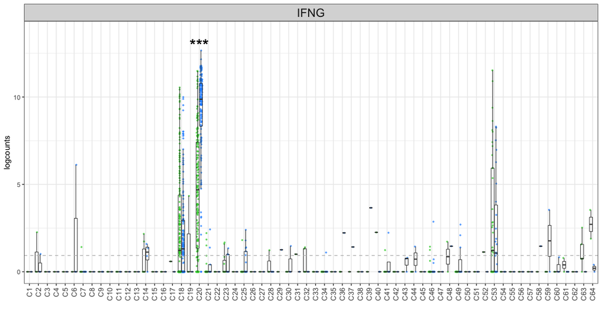

```r
plot_tgram(tt[gene_name == "IFNG"], dot_shape = 20, boxplot_stroke = .35,
  col_wt = "limegreen",col_mut = "dodgerblue1",
  label_font_size = 10, show_legend = FALSE)
```

Let’s focus on the three most abundant clonotypes:

[figure not shown]

```r
pl <- lapply(genes_of_interest, function(x){
  PP <- plot_tgram(tt[gene_name == x & id %in% c("C18","C20","C53")],
    dot_size = 3, dot_shape = 20, boxplot_stroke = 1.15,
    col_wt = "limegreen",col_mut = "dodgerblue1",
    label_font_size = 16, show_legend = TRUE)
  return(PP)})
ABCutilities::MultiPlotList(pl, cols = 4, title = "Genes of interest")
```

### “signal-noise” plots

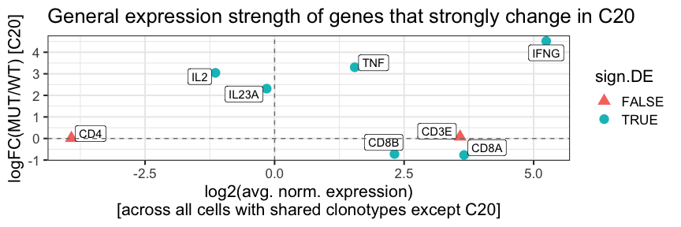

```r
goi.meanExprs <- tt[ id != "C20", mean((2^logcounts)-1), by = "gene_name"]
setnames(goi.meanExprs, "V1","mean.norm.expression")

goi.logFC_C20 <- as.data.frame(delist.both$C20$findMarkers_results$MUT) %>%
  as.data.table(., keep.rownames = TRUE) %>% .[rn %in% genes_of_interest]
setnames(goi.logFC_C20, "rn", "gene_name")
goi.logFC_C20$sign.DE <- ifelse(goi.logFC_C20$gene_name %in% delist.both$C20$marker_IDs$gene_symbol, TRUE, FALSE)

## plot
goi.meanExprs[goi.logFC_C20, on = "gene_name"] %>%
  ggplot(., aes(y = logFC.WT, x = log2(mean.norm.expression), key = gene_name)) +
  geom_point(size = 4, aes(color = sign.DE, shape = sign.DE)) +
  ggrepel::geom_label_repel(aes(label = gene_name)) +
  ylab("logFC(MUT/WT) [C20]") + xlab("log2(avg. norm. expression)\n[across all cells with shared clonotypes except C20]") +
  ggtitle("General expression strength of genes that strongly change in C20") +
  geom_hline(yintercept = 0, linetype="dashed", color = "grey50") +
  geom_vline(xintercept = 0, linetype="dashed", color = "grey50") +
  scale_shape_manual(values = c(17,16))
```

This plot depicts that IFNG (a) has the highest logFC of the DE genes in C20 and (b) it is strongly expressed in all other clonotypes as well. *CD3E*, on the other hand, is also strongly expressed across all clonotypes, but does not show a big difference in C20-WT compared to C20-MUT. *IL2* is an example of a gene that has a high logFC in C20, but it is rather weakly expressed across all other clonotypes.

Let’s do it for all DEG of C20!

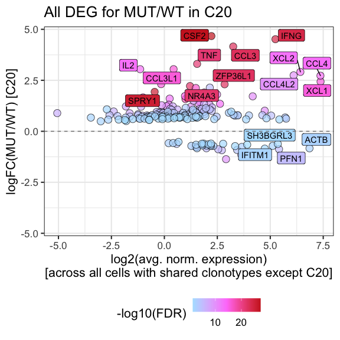

```r
deg.logFC_C20 <- as.data.frame(delist.both$C20$findMarkers_results$MUT) %>%
  as.data.table(., keep.rownames = TRUE) %>% .[FDR <= 0.05]
setnames(deg.logFC_C20, "rn", "gene_name")

deg.meanExprs <- scABC2::make_long_dt(sce.shared,
  genes = unique(deg.logFC_C20$gene_name),
  exprs_values = "logcounts",
  include_metaData = "id") %>%
  .[id != "C20", mean((2^logcounts)-1), by = c("gene_name")]
setnames(deg.meanExprs, "V1","mean.norm.expression")

## plot
degs <- deg.meanExprs[deg.logFC_C20, on = "gene_name"]
ymax <- max(abs(degs$logFC.WT))
ymin <- -1 * ymax

ggplot(degs, aes(y = logFC.WT, x = log2(mean.norm.expression), key = gene_name, fill = -log10(FDR))) +
  geom_point(alpha = .7, size = 4, shape = 21) +
  ggrepel::geom_label_repel(data = degs[ (logFC.WT >= 2.5) |  -log10(FDR) >= 20 |
      (logFC.WT >= 2 & log2(mean.norm.expression) > 5) |
      (logFC.WT < 0 & log2(mean.norm.expression) > 5) ],
    aes(label = gene_name)) +
  ylab("logFC(MUT/WT) [C20]") +
  xlab("log2(avg. norm. expression)\n[across all cells with shared clonotypes except C20]") +
  ggtitle("All DEG for MUT/WT in C20") +
  scale_fill_gradientn(colours = c("lightskyblue1","orchid1","firebrick3"))+
  coord_cartesian(ylim = c(ymin, ymax)) +
  geom_hline(yintercept = 0, linetype = "dashed", color = "grey50") +
  theme(legend.position = "bottom")
```

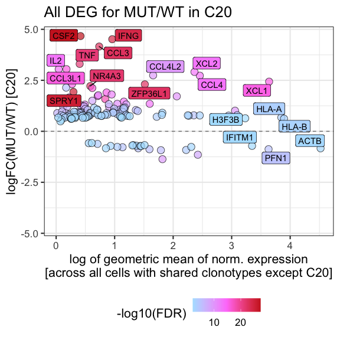

```r
deg.logFC_C20 <- as.data.frame(delist.both$C20$findMarkers_results$MUT) %>%
  as.data.table(., keep.rownames = TRUE) %>% .[FDR <= 0.01]
setnames(deg.logFC_C20, "rn", "gene_name")

deg.meanExprs2 <- scABC2::make_long_dt(sce.shared,
  genes = unique(deg.logFC_C20$gene_name),
  exprs_values = "logcounts",
  include_metaData = "id") %>%
  .[id != "C20", 2^mean(logcounts), by = c("gene_name")]
setnames(deg.meanExprs2, "V1","geometric.mean")

## plot
degs2 <- deg.meanExprs2[deg.logFC_C20, on = "gene_name"]
ymax <- max(abs(degs2$logFC.WT))
ymin <- -1 * ymax

ggplot(degs2, aes(y = logFC.WT, x = log(geometric.mean), key = gene_name, fill = -log10(FDR))) +
  geom_point(alpha = .7, size = 4, shape = 21) +
  ggrepel::geom_label_repel(data = degs2[ (logFC.WT >= 2.5 | geometric.mean > 25 | -log10(FDR) >= 20)],
    aes(label = gene_name)) +
  ylab("logFC(MUT/WT) [C20]") +
  xlab("log of geometric mean of norm. expression\n[across all cells with shared clonotypes except C20]") +
  ggtitle("All DEG for MUT/WT in C20") +
  scale_fill_gradientn(colours = c("lightskyblue1","orchid1","firebrick3"))+
  coord_cartesian(ylim = c(ymin, ymax)) +
  geom_hline(yintercept = 0, linetype = "dashed", color = "grey50") +
  theme(legend.position = "bottom")
```

# Enrichment analyses

Possible gene sets of interest:

- KEGG_T_CELL_RECEPTOR_SIGNALING_PATHWAY
- PID_CD8_TCR_PATHWAY
- PID_TCR_PATHWAY
- BIOCARTA_TCR_PATHWAY
- REACTOME_TCR_SIGNALING

```r
## extract_logFC
degns.c20 <- delist.both[["C20"]]$findMarkers_results$MUT %>%
  as.data.frame %>% as.data.table(., keep.rownames=TRUE)
setnames(degns.c20, "rn","gene_symbol")

# For the comparison with the publicly available gene sets, we'll use the Entrez IDs.
##  retrieve_entrez_ids
eg <-  clusterProfiler::bitr(degns.c20$gene_symbol,
  fromType="SYMBOL", toType="ENTREZID",
  OrgDb="org.Hs.eg.db") %>% as.data.table
```

```
#>
#> Warning in clusterProfiler::bitr(degns.c20$gene_symbol, fromType = "SYMBOL", :
#> 14.81% of input gene IDs are fail to map...
```

```r
setnames(eg, names(eg), c("gene_symbol", "ENTREZID"))
degns.c20 <- eg[degns.c20, on = "gene_symbol"]
```

For GSEA, we need a vector of *all* genes with the respective logFCs. This can also be used to color the enrichment plots down the line.

```r
degns.c20.rnks <- get_ranks(degns.c20, rank_by = "logFC.WT")
```

## ORA

Over-representation analysis depends on a simple comparison of two lists of gene names. One list contains the DEG for the C20 comparison of MUT/WT cells, the other list corresponds to a specific gene set.

There are numerous collections of gene sets, the most popular include the ones provided by the Broad’s MSigDB, such as “HALLMARK” gene sets, KEGG pathways, pathways defined by REACTOME etc.

The following sections show the results for the simple ORA using different collections of gene sets.

### Hallmark gene sets

```r
## MSigDB Hallmark gene set
#gs <- system.file("extdata", "h.all.v7.0.entrez.gmt", package = "KlebanoffVDJData2020")
gs <- system.file("extdata", "h.all.v7.0.entrez.gmt", package = "Klebanoff21LT2", mustWork = TRUE)
hmgs <- clusterProfiler::read.gmt(gs)

## test for enrichment
ora_hallmark <- clusterProfiler::enricher(degns.c20[FDR <= 0.05]$ENTREZID,
  TERM2GENE = hmgs)
ora_hallmark <- DOSE::setReadable(ora_hallmark, 'org.Hs.eg.db', 'ENTREZID')
```

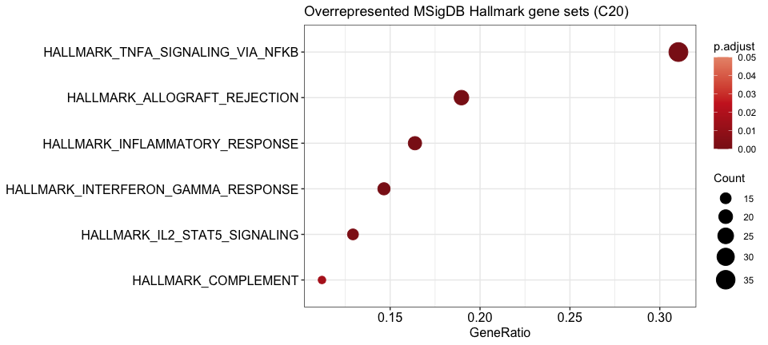

```r
dotplot(ora_hallmark) +
  ggtitle("Overrepresented MSigDB Hallmark gene sets (C20)") +
  scale_color_gradientn(colours =rev(c("darksalmon",
    "firebrick3", "firebrick4")), limits = c(0, 0.05))
```

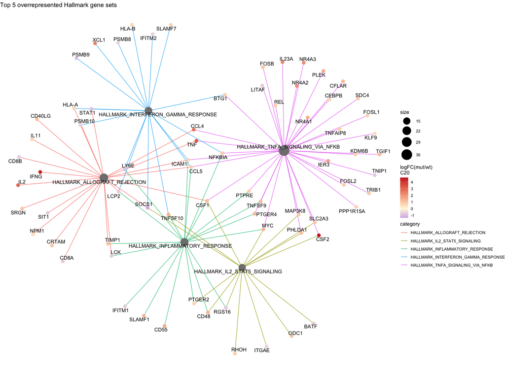

```r
cnetplot(ora_hallmark,
  foldChange = degns.c20.rnks, colorEdge = TRUE) +
  ggtitle("Top 5 overrepresented Hallmark gene sets") +
  scale_color_gradient2(name = "logFC(mut/wt)\nC20",
    low = "blue1", mid = "cornsilk1", high = "firebrick3", midpoint = 0)
```

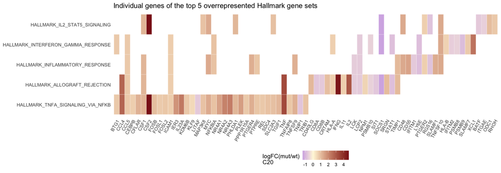

```r
heatplot(ora_hallmark,
  foldChange=degns.c20.rnks, showCategory = 5) +
  ggtitle("Individual genes of the top 5 overrepresented Hallmark gene sets") +
  scale_fill_gradient2(name = "logFC(mut/wt)\nC20",
    low = "blue2", mid = "cornsilk1",
    high = "firebrick4", midpoint = 0) +
    theme(legend.position = "bottom")
```

### KEGG

```r
## MSigDB KEGG gene set
gs <- system.file("extdata", "c2.cp.kegg.v7.0.entrez.gmt", package = "Klebanoff21LT2")
hmgs <- clusterProfiler::read.gmt(gs)
ora_kegg <- clusterProfiler::enricher(degns.c20[FDR <= 0.05]$ENTREZID, TERM2GENE = hmgs)
ora_kegg <- DOSE::setReadable(ora_kegg, 'org.Hs.eg.db', 'ENTREZID')
```

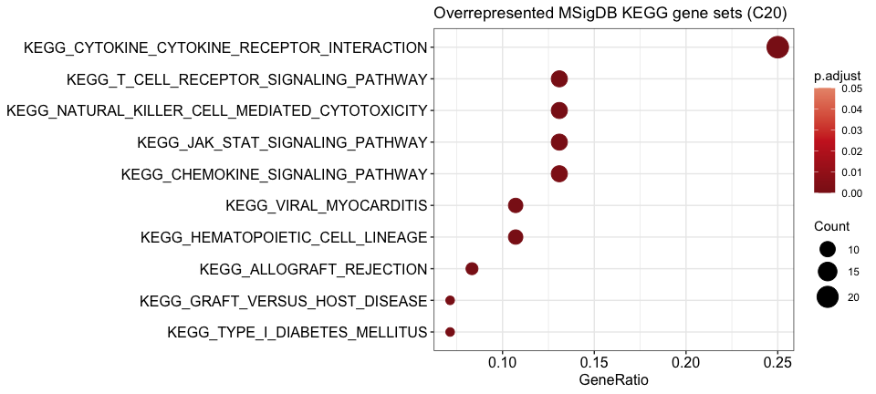

```r
dotplot(ora_kegg) +
  ggtitle("Overrepresented MSigDB KEGG gene sets (C20)") +
  scale_color_gradientn(colours =rev(c("darksalmon",
    "firebrick3", "firebrick4")), limits = c(0, 0.05))
```

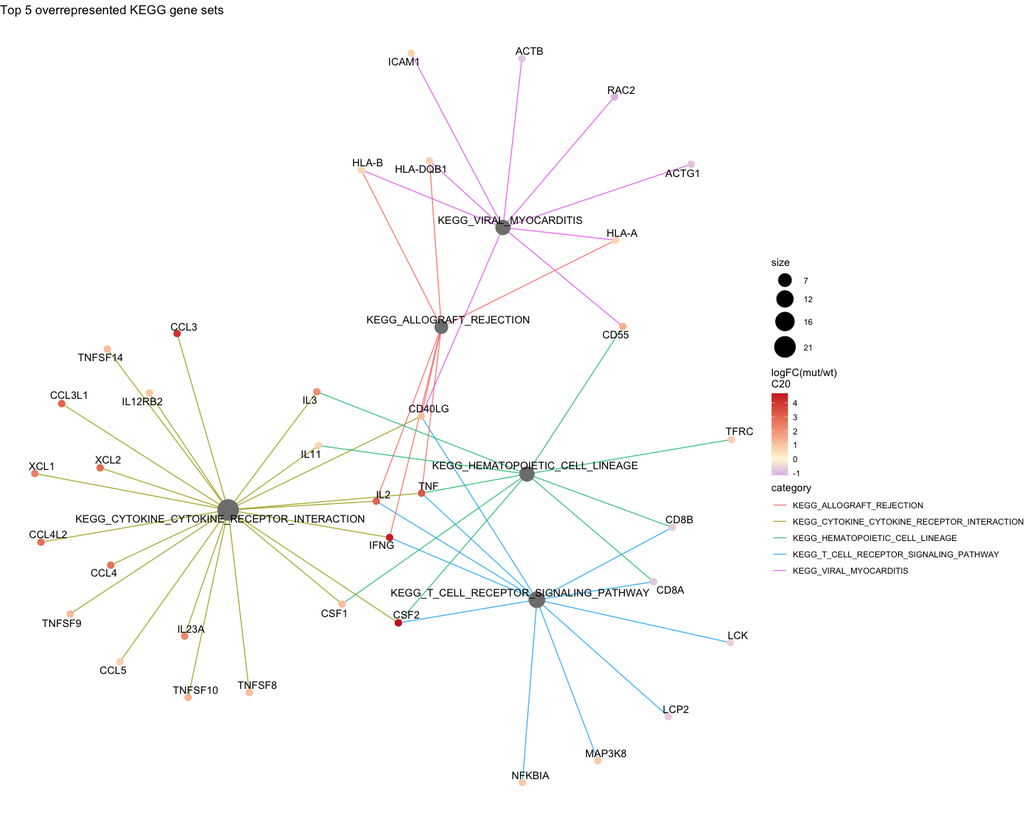

```r
cnetplot(ora_kegg,
  foldChange = degns.c20.rnks, colorEdge = TRUE) +
  ggtitle("Top 5 overrepresented KEGG gene sets") +
  scale_color_gradient2(name = "logFC(mut/wt)\nC20",
    low = "blue1", mid = "cornsilk1", high = "firebrick3", midpoint = 0)
```

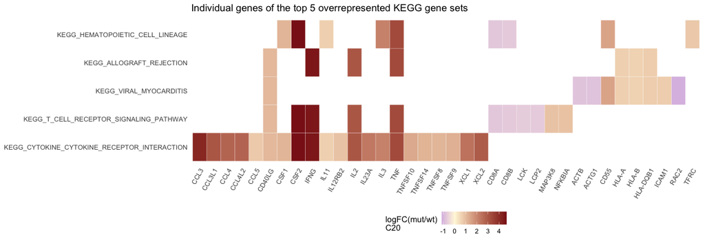

```r
heatplot(ora_kegg,
  foldChange=degns.c20.rnks, showCategory = 5) +
  ggtitle("Individual genes of the top 5 overrepresented KEGG gene sets") +
  scale_fill_gradient2(name = "logFC(mut/wt)\nC20",
    low = "blue2", mid = "cornsilk1",
    high = "firebrick4", midpoint = 0) +
    theme(legend.position = "bottom")
```

### REACTOME

```r
## MSigDB REACTOME gene set
gs <- system.file("extdata", "c2.cp.reactome.v7.0.entrez.gmt",
  package = "Klebanoff21LT2", mustWork = TRUE)
hmgs <- clusterProfiler::read.gmt(gs)
ora_react <- clusterProfiler::enricher(degns.c20[FDR <= 0.05]$ENTREZID, TERM2GENE = hmgs)
ora_react <- DOSE::setReadable(ora_react, 'org.Hs.eg.db', 'ENTREZID')
```

[figure not shown]

```r
dotplot(ora_react) +
  ggtitle("Overrepresented MSigDB REACTOME gene sets (C20)") +
  scale_color_gradientn(colours =rev(c("darksalmon",
    "firebrick3", "firebrick4")), limits = c(0, 0.05))
```

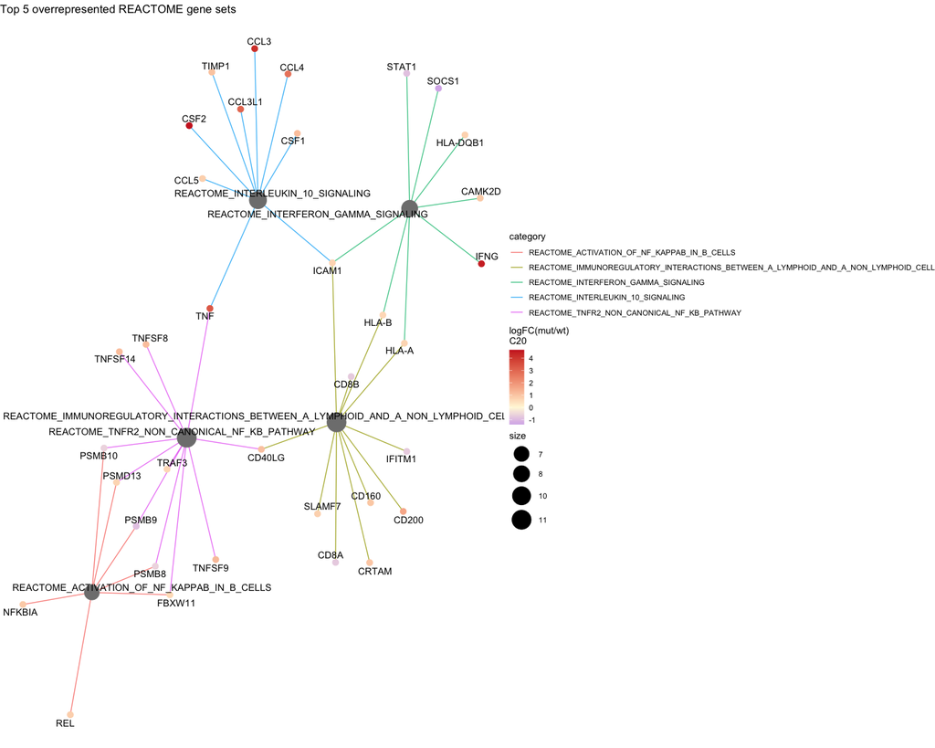

```r
cnetplot(ora_react,
  foldChange = degns.c20.rnks, colorEdge = TRUE) +
  ggtitle("Top 5 overrepresented REACTOME gene sets") +
  scale_color_gradient2(name = "logFC(mut/wt)\nC20",
    low = "blue1", mid = "cornsilk1", high = "firebrick3",
    midpoint = 0)
```

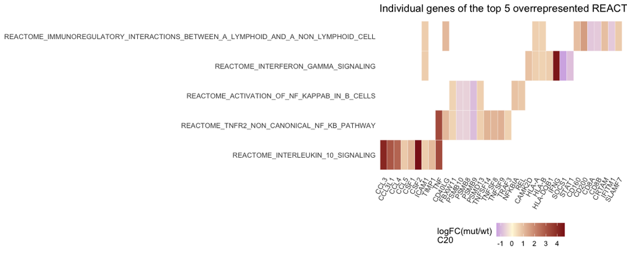

```r
heatplot(ora_react,
  foldChange=degns.c20.rnks, showCategory = 5) +
  ggtitle("Individual genes of the top 5 overrepresented REACTOME gene sets") +
  scale_fill_gradient2(name = "logFC(mut/wt)\nC20",
    low = "blue2", mid = "cornsilk1",
    high = "firebrick4", midpoint = 0) +
    theme(legend.position = "bottom")
```

### PID

```r
## MSigDB REACTOME gene set
gs <- system.file("extdata", "c2.cp.pid.v7.0.entrez.gmt",
  package = "Klebanoff21LT2", mustWork=TRUE)
hmgs <- clusterProfiler::read.gmt(gs)
ora_pid <- clusterProfiler::enricher(degns.c20[FDR <= 0.05]$ENTREZID, TERM2GENE = hmgs)
ora_pid <- DOSE::setReadable(ora_pid, 'org.Hs.eg.db', 'ENTREZID')
```

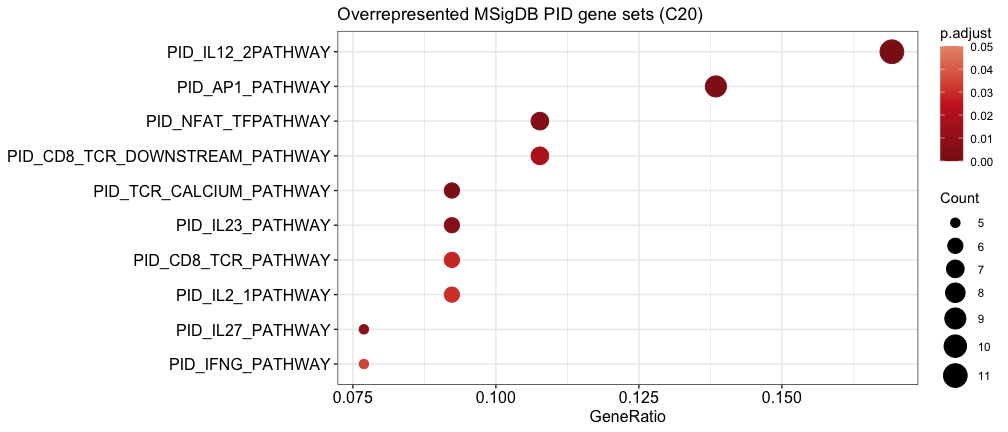

```r
dotplot(ora_pid) +
  ggtitle("Overrepresented MSigDB PID gene sets (C20)") +
  scale_color_gradientn(colours =rev(c("darksalmon",
    "firebrick3", "firebrick4")), limits = c(0, 0.05))
```

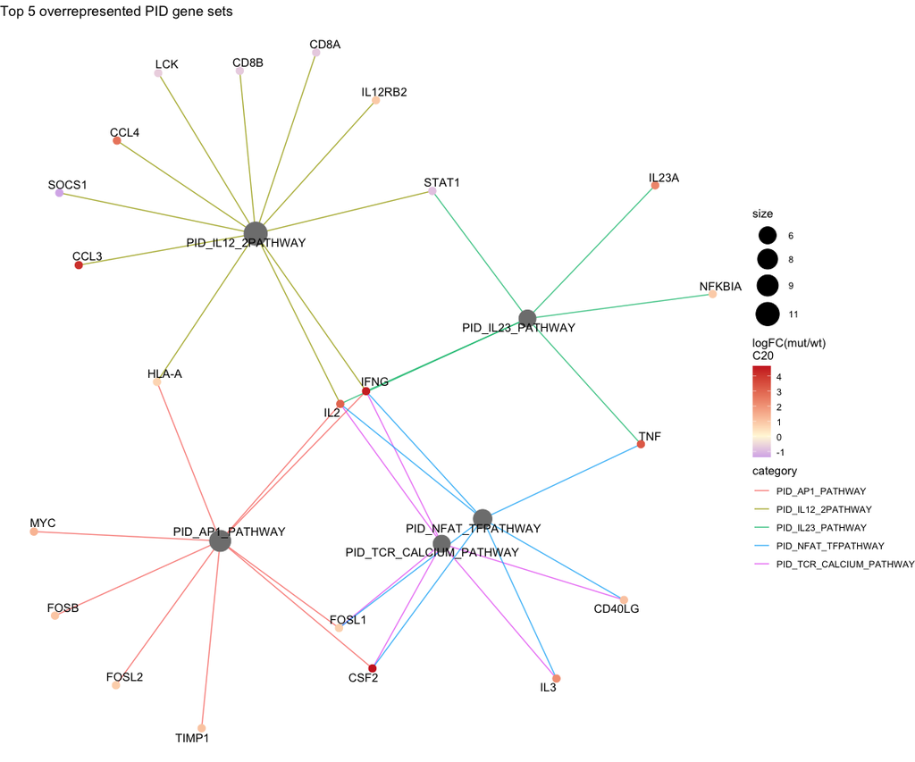

```r
cnetplot(ora_pid,
  foldChange = degns.c20.rnks, colorEdge = TRUE) +
  ggtitle("Top 5 overrepresented PID gene sets") +
  scale_color_gradient2(name = "logFC(mut/wt)\nC20",
    low = "blue1", mid = "cornsilk1", high = "firebrick3",
    midpoint = 0)
```

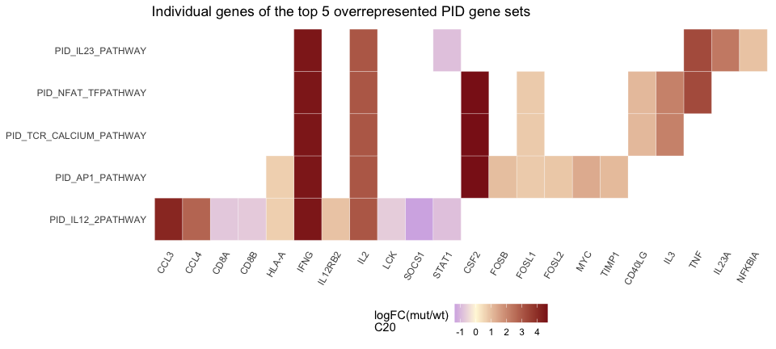

```r
heatplot(ora_pid,
  foldChange=degns.c20.rnks, showCategory = 5) +
  ggtitle("Individual genes of the top 5 overrepresented PID gene sets") +
  scale_fill_gradient2(name = "logFC(mut/wt)\nC20",
    low = "blue2", mid = "cornsilk1",
    high = "firebrick4", midpoint = 0) +
    theme(legend.position = "bottom")
```

## GSEA

```r
library(fgsea)
```

### REACTOME

```r
## REACTOME
library(reactome.db)
### retrieve pathways
pw_reactome <- fgsea::reactomePathways(genes = degns.c20$ENTREZID)

## run FGSEA
fgsea_reactome_degns.c20  <- fgsea(pathways = pw_reactome,
  stats = degns.c20.rnks,
  minSize = 15, maxSize = 500, nperm = 100000)

usethis::use_data(fgsea_reactome_degns.c20, overwrite = TRUE)
```

```r
## fgsea_reactome
data("fgsea_reactome_degns.c20", package = "Klebanoff21LT2", mustWork=TRUE)
### retrieve pathways
library(reactome.db)
pw.reactome <- fgsea::reactomePathways(genes = degns.c20$ENTREZID)
# the most significant pathway
fgsea_reactome_degns.c20[order(pval),][1,]
```

```
#>              pathway         pval        padj        ES     NES nMoreExtreme
#> 1: Signaling by GPCR 1.174136e-05 0.002484752 0.5995028 1.74261            0
#>    size                       leadingEdge
#> 1:  464 6348,6349,6846,9560,6351,6375,...
```

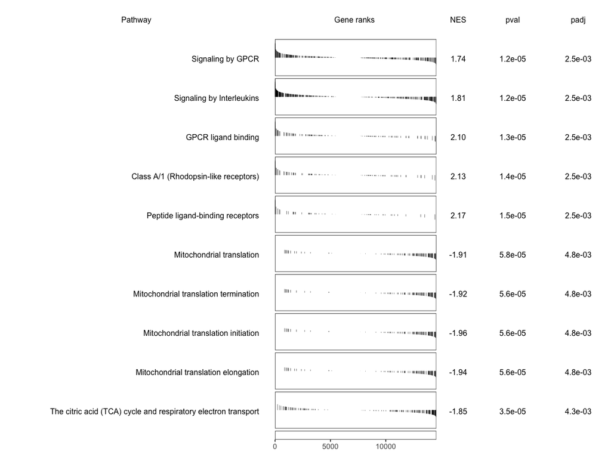

```r
topPWs <- extract_top_pw(fgsea_reactome_degns.c20, n_pw = 5,
  direction = "both", p_adj_threshold = 0.01)

plotGseaTable(pw.reactome[topPWs], degns.c20.rnks,
  fgsea_reactome_degns.c20,
  gseaParam = 0.5)
```

### KEGG

```r
## KEGG

### clusterProfiler-way of doing FGSEA -- will produce
### a different kind of object, i.e. one that can be used
### with the usual clusterProfiler visualization functions
#fgsea_kegg_degns.c20 <- clusterProfiler::gseKEGG(
#  geneList = degns.c20.rnks,
#  organism = 'hsa', nPerm = 1000, minGSSize = 120,
#  pvalueCutoff = 0.05, verbose  = FALSE,
#  by = "fgsea")

### FGSEA direct
gs <- system.file("extdata", "c2.cp.kegg.v7.0.entrez.gmt",
  package = "Klebanoff21LT2", mustWork = TRUE)

pw.kegg <- fgsea::gmtPathways(gs)
fgsea_kegg_degns.c20  <- fgsea(
  pathways = pw.kegg,
  stats = degns.c20.rnks,
  minSize = 15, maxSize = 500, nperm = 100000)

usethis::use_data(fgsea_kegg_degns.c20, overwrite = TRUE)
```

```r
gs <- system.file("extdata", "c2.cp.kegg.v7.0.entrez.gmt", package = "Klebanoff21LT2", mustWork = TRUE)
pw.kegg <- fgsea::gmtPathways(gs)
## fgsea_kegg_degns.c20
data("fgsea_kegg_degns.c20", package = "Klebanoff21LT2")
```

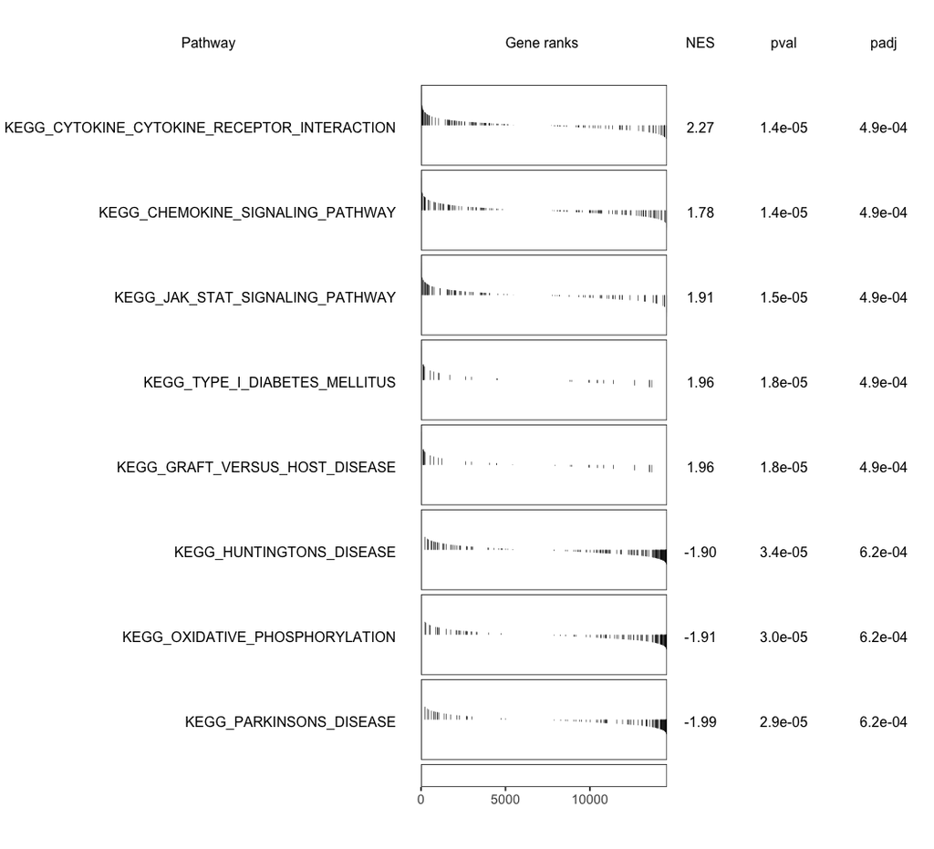

```r
fgsea_res <- fgsea_kegg_degns.c20
pws <- pw.kegg
topPWs <- extract_top_pw(fgsea_res, n_pw = 5,
  direction = "both", p_adj_threshold = 0.01)
plotGseaTable(pws[topPWs], degns.c20.rnks,
  fgseaRes = fgsea_res, gseaParam = 0.5)
```

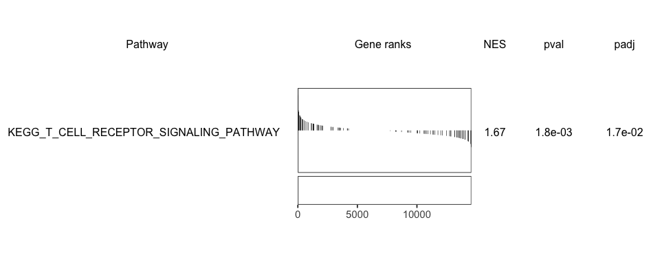

```r
plotGseaTable(pws["KEGG_T_CELL_RECEPTOR_SIGNALING_PATHWAY"],
  degns.c20.rnks,
  fgseaRes = fgsea_res, gseaParam = 0.5)
```

### PID

```r
gs <- system.file("extdata", "c2.cp.pid.v7.0.entrez.gmt",
  package = "Klebanoff21LT2", mustWork=TRUE)
pw.pid <- fgsea::gmtPathways(gs)
fgsea_pid_degns.c20  <- fgsea(
  pathways = pw.pid,
  stats = degns.c20.rnks,
  minSize = 15, maxSize = 500, nperm = 100000)

usethis::use_data(fgsea_pid_degns.c20, overwrite = TRUE)
```

```r
gs <- system.file("extdata", "c2.cp.pid.v7.0.entrez.gmt",
  package = "Klebanoff21LT2", mustWork=TRUE)
pw.pid <- fgsea::gmtPathways(gs)
data("fgsea_pid_degns.c20",  package = "Klebanoff21LT2")
```

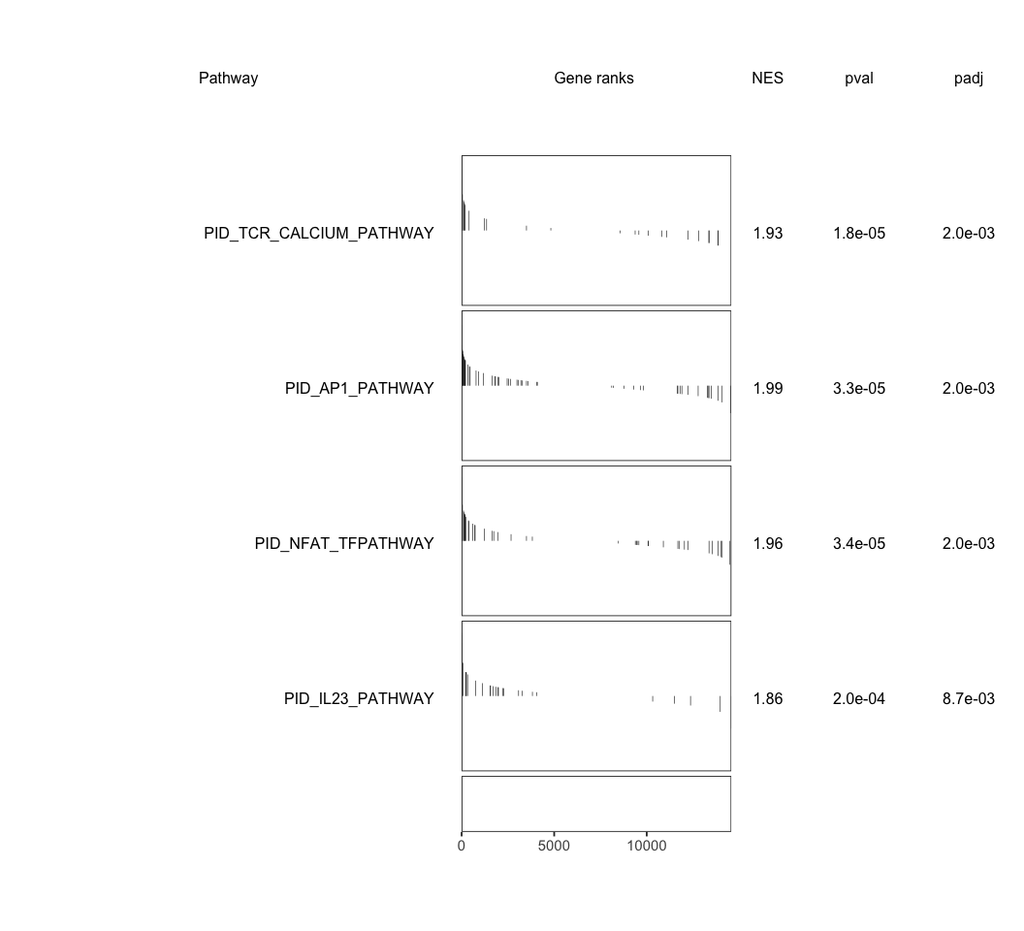

```r
fgsea_res <- fgsea_pid_degns.c20
pws <- pw.pid
topPWs <- extract_top_pw(fgsea_res, n_pw = 5,
  direction = "both", p_adj_threshold = 0.01)
plotGseaTable(pws[topPWs], degns.c20.rnks,
  fgseaRes = fgsea_res, gseaParam = 0.5)
```

# Saving tables for Chris

```r
with_deg <- lapply(delist.both, function(x) !is.null(x[[2]])) %>% unlist
## will save them all in one xlsx collection of spreadsheets
outl <- lapply(names(delist.both), function(x){
  degns <- delist.both[[x]]$findMarkers_results$MUT %>% as.data.frame %>%
    as.data.table(., keep.rownames="gene_symbol")
  degns[, neglog10.pVal := -1*log10(p.value)]
  degns[, neglog10.FDR := -1*log10(FDR)]
  return(data.frame(degns))
})
names(outl) <- paste(names(delist.both), "DEG_Mut-vs-Wt", sep = "_")

## add basic information about the clonotypes
cinfo <-  clonotype_ids[id %in% names(delist.both)]
setnames(cinfo, c("MUT.21LT2", "WT.21LT2"), c("n_cells_in_MUT", "n_cells_in_WT"))
setorder(cinfo, id)
outl$clonotype_info <- data.frame(cinfo)

openxlsx::write.xlsx(outl,
  file = "~/Documents/Projects/2018-10_Smita/2020-03_reprocessing_21LT2/DEgenes_21LT2.xlsx")
```

```r
goi <- c("CD8A","CD3E","CD4")
outl2 <- lapply(goi, function(x){
  scABC2::make_long_dt(sce.shared, genes = x,
    include_metaData = c("Sample","id"))
})
names(outl2) <- goi
openxlsx::write.xlsx(outl2,
  file = "~/Documents/Projects/2018-10_Smita/2020-03_reprocessing_21LT2/logcounts_TcellMarkers_21LT2.xlsx")
```

```r
## C20
degns.c20[, neglog10.pVal := -1*log10(p.value)]
degns.c20[, neglog10.FDR := -1*log10(FDR)]
write.table(as.data.frame(degns.c20), quote = F, sep = "\t", row.names=F,
  file = "~/Documents/Projects/2018-10_Smita/2020-03_reprocessing_21LT2/DEgenes_21LT2_C20_mut_vs_wt.txt")

degns.c18 <- delist.both[["C18"]]$findMarkers_results$MUT %>%
  as.data.frame %>% as.data.table(., keep.rownames="gene_symbol")
degns.c18[, neglog10.pVal := -1*log10(p.value)]
degns.c18[, neglog10.FDR := -1*log10(FDR)]
as.data.frame(degns.c18) %>%
  write.table(, quote = F, sep = "\t", row.names=F,
  file = "~/Documents/Projects/2018-10_Smita/2020-03_reprocessing_21LT2/DEgenes_21LT2_C18_mut_vs_wt.txt")

degns.c53 <- delist.both[["C53"]]$findMarkers_results$MUT %>%
  as.data.frame %>% as.data.table(., keep.rownames="gene_symbol")
degns.c53[, neglog10.pVal := -1*log10(p.value)]
degns.c53[, neglog10.FDR := -1*log10(FDR)]
as.data.frame(degns.c53) %>%
  write.table(, quote = F, sep = "\t", row.names=F,
  file = "~/Documents/Projects/2018-10_Smita/2020-03_reprocessing_21LT2/DEgenes_21LT2_C53_mut_vs_wt.txt")
```

```r
## saving enrichment results as tables
write.table(as.data.frame(ora_hallmark), quote =F, row.names = F,
  sep = ",", file = "~/Documents/Projects/2018-10_Smita/data/degC20_ora_hallmark.csv")

write.table(as.data.frame(ora_kegg), quote =F, row.names = F,
  sep = ",", file = "~/Documents/Projects/2018-10_Smita/data/degC20_ora_kegg.csv")
```

```
# Previously saved for Chris
## table of tgrams
dcast(tt, gene_name ~ cell + Sample, value.var = "logcounts") %>%
  as.data.frame %>% write.table(., quote = F, row.names =F, col.names = T, sep = ",",
    file = "~/Documents/Projects/2018-10_Smita/data/logcountsPerCell_IFNG_et_al.csv")

## table of 'signal-noise-plots'
write.table(as.data.frame(degs),
  file = "~/Documents/Projects/2018-10_Smita/data/DEG-C20_mean-norm-expression.csv",
  row.names = F, quote = F, sep = ",")

write.table(as.data.frame(degs2),
  file = "~/Documents/Projects/2018-10_Smita/data/DEG-C20_geoMean-norm-expression.csv",
  row.names = F, quote = F, sep = ",")
```